# Econometria III Aula 6

Mestrado Profissional em Administração

Prof. Dr. Washington Santos da Silva

23/11/2026

## Programação da aula

### Aula anterior

- Modelos dinâmicos para dados em painel II
  - O problema: persistência em dados em painel
  - A tentativa com Efeitos Fixos e o Viés de Nickell
  - GMM em diferenças
  - GMM em sistema
  - Estrutura de decisão
  - Resumo

### Hoje

- Causalidade e desenhos de pesquisa em Econometria Aplicada
- Diferença-em-Diferenças (DiD)
  - Diferença-em-Diferenças com painel com dois períodos
  - Diferença-em-Diferenças com painel com múltiplos períodos

Causalidade e desenhos de pesquisa em Econometria Aplicada

## Associação estatística e causalidade

### Empréstimos estudantis e conclusão da graduação (Angrist e Pischke, 2014)

Nos Estados Unidos, estudantes com **maiores empréstimos estudantis** tendem a apresentar **menores taxas de conclusão** da graduação.

- **Associação:** estudantes mais endividados apresentam menores taxas de conclusão.
- **Causalidade:** contrair empréstimos para financiar os estudos **reduz a probabilidade de concluir a graduação**?

**O problema (viés de seleção):** estudantes de famílias com menos recursos tendem a contrair mais empréstimos e, por fatores associados à origem familiar, podem apresentar menores taxas de conclusão, independentemente do endividamento.

$\implies$ A **associação observada não permite, por si só, identificar o efeito causal** do endividamento sobre a conclusão da graduação.

## Comparações *ceteris paribus*

### O exemplo dos “gêmeos virtuais” (Angrist e Pischke, 2014)

Imagine dois estudantes **idênticos em todos os demais aspectos**, incluindo os recursos familiares e a escolaridade dos pais.

- **Estudante A:** financia a graduação com empréstimos.
- **Estudante B:** financia a graduação com recursos poupados.

**Comparação *ceteris paribus*:** se a única diferença entre os estudantes fosse a forma de financiamento, uma diferença na conclusão da graduação poderia ser atribuída ao endividamento.

Essa comparação ideal pressupõe o **controle dos demais fatores que influenciam o resultado**, evitando o problema dos **fatores de confusão**.

**O problema:** na prática, estudantes endividados e não endividados podem diferir sistematicamente em características que também afetam a conclusão da graduação.

Essas diferenças podem produzir viés de seleção e, nas regressões, endogeneidade por variáveis omitidas, tornando o estimador de MQO viesado e inconsistente.

## Experimentos aleatorizados

### Atribuição aleatória e comparabilidade (Angrist e Pischke, 2014)

Imagine que a **oferta de auxílio financeiro** aos estudantes seja determinada por **sorteio**, formando dois grupos:

- **Tratamento:** estudantes que recebem a oferta.
- **Controle:** estudantes que não recebem a oferta.

A aleatorização torna a atribuição do tratamento **independente de fatores que também influenciam a conclusão da graduação**, como a renda familiar e a escolaridade dos pais.

Assim, evita o viés de seleção na atribuição do tratamento e o viés de variáveis omitidas na estimação do efeito causal da oferta.

$\implies$ Os grupos são **comparáveis em média**, permitindo identificar o **efeito causal da oferta de auxílio** sobre a conclusão da graduação.

**Importante:** a aleatorização não garante grupos idênticos em cada amostra. Diferenças ocasionais entre eles ainda podem ocorrer.

## Identificação causal em estudos observacionais

### O experimento ideal como referência (Angrist e Pischke, 2014, p. xiv)

Em **estudos observacionais**, o pesquisador não atribui o tratamento por sorteio. Assim, os grupos podem diferir em fatores que também influenciam os resultados, produzindo viés de seleção.

**Pergunta central:** que experimento gostaríamos de realizar para identificar o efeito causal de interesse?

**Estratégia de identificação:** explorar fontes de variação, como mudanças de políticas, regras institucionais ou acontecimentos naturais, justificando **por que essas variações permitem uma comparação causal**, sob determinadas hipóteses.

$\implies$ A **interpretação causal** depende da **credibilidade do desenho de pesquisa** e das **hipóteses que justificam a comparação**, não apenas do estimador utilizado.

## A revolução da credibilidade

### A transformação da econometria aplicada

**Leamer (1983):** criticou a fragilidade dos resultados econométricos diante de mudanças nas especificações dos modelos e defendeu a realização de **análises de sensibilidade**.

**Angrist e Pischke (2010):** argumentam que a crescente credibilidade da microeconometria aplicada decorreu principalmente da ênfase na **qualidade dos desenhos de pesquisa**, com destaque para **experimentos aleatorizados** e **estudos quase-experimentais** que exploram fontes de variação capazes de sustentar inferências causais.

$\implies$ A questão fundamental não é apenas **qual modelo estimar**, mas **por que a comparação utilizada permite identificar um efeito causal**.

**Ressalva de Leamer (2010):** experimentos e quase-experimentos não dispensam a avaliação crítica das **hipóteses**, da **sensibilidade dos resultados** e dos **limites de generalização** das conclusões.

## Estratégias de identificação causal

### As cinco ferramentas (*Furious Five*) (Angrist e Pischke, 2014)

- **Atribuição aleatória (experimentos aleatorizados):** utiliza o sorteio para atribuir ou oferecer o tratamento, formando grupos comparáveis em média e permitindo identificar o efeito causal da atribuição.
- **Regressão:** compara resultados ajustando por características observadas; a interpretação causal exige o controle adequado dos fatores de confusão relevantes.
- **Variáveis instrumentais (VI):** explora a variação do tratamento associada a um instrumento relevante e exógeno, que afeta o resultado apenas por meio do tratamento.
- **Regressão com descontinuidade (RDD):** compara unidades próximas a um ponto de corte que altera a probabilidade de tratamento, sob condições de comparabilidade local.
- **Diferenças em diferenças (DiD):** compara as mudanças nos resultados entre grupos tratados e de controle, antes e depois de uma intervenção, sob a hipótese de tendências paralelas na ausência do tratamento.

$\implies$ **Nesta aula:** DiD como estratégia de identificação causal em estudos observacionais.

## Aplicações de inferência causal em Finanças

### Economia e Finanças Comportamentais

- **[Bursztyn et al. (2014)](https://doi.org/10.3982/ECTA11991)** — *Econometrica* | **Brasil, experimento aleatorizado**: os investidores seguem seus pares por aprendizado social ou pela posse de ativos?
- **[Bertrand e Morse (2011)](https://doi.org/10.1111/j.1540-6261.2011.01698.x)** — *Journal of Finance* | **Experimento aleatorizado**: informações mais claras sobre os custos do crédito reduzem a contratação de empréstimos caros?

### Finanças Corporativas e Investimentos

- **[Carvalho (2014)](https://doi.org/10.1111/jofi.12130)** — *Journal of Finance* | **Brasil, quase-experimento**: o crédito de bancos públicos influencia decisões de emprego das empresas em períodos eleitorais?
- **[Yagan (2015)](https://doi.org/10.1257/aer.20130098)** — *American Economic Review* | **DiD**: a redução do imposto sobre dividendos estimula o investimento corporativo?
- **[Chang, Hong e Liskovich (2015)](https://doi.org/10.1093/rfs/hhu041)** — *Review of Financial Studies* | **RDD**: a inclusão de ações no índice Russell 2000 altera seus preços?

Diferença-em-Diferenças com painel com dois períodos

## O problema: a política funcionou?

### Um estado elevou o salário mínimo. O emprego caiu?

Em 1º de abril de 1992, New Jersey elevou seu salário mínimo de US$ 4,25 para US$ 5,05. O estado vizinho, Pennsylvania, manteve o salário mínimo em US$ 4,25.

**Previsão da teoria padrão:** se o salário mínimo superar o salário de equilíbrio, a quantidade de trabalho demandada tende a diminuir, enquanto a quantidade ofertada tende a aumentar, *ceteris paribus*.

Trabalhadores de baixa remuneração podem ganhar mais por hora, mas alguns podem perder o emprego ou trabalhar menos horas.

**A pergunta:** como medir o efeito causal dessa política?

Não podemos observar *o que teria ocorrido* em NJ sem o aumento. Esse cenário não observado é o **contrafactual**.

$\implies$ Precisamos de uma estratégia que isole o efeito da política de tudo o mais que muda ao mesmo tempo.

## Salário mínimo e emprego: Card e Krueger (1994)

### O desenho da pesquisa

Card e Krueger investigaram o efeito do aumento do salário mínimo sobre o **emprego em restaurantes de *fast-food*** de Nova Jersey (NJ) e da Pensilvânia (PA).

- **Antes:** entrevistaram **410 restaurantes** em NJ e PA (fevereiro–março de 1992).
- **Depois:** reentrevistaram **399 desses estabelecimentos** (novembro–dezembro de 1992).
- **Estrutura dos dados:** painel com **dois períodos**, acompanhando os mesmos restaurantes antes e depois da intervenção.

**Estratégia de comparação:** Nova Jersey constitui o grupo de **tratamento**, enquanto a Pensilvânia constitui o grupo de **controle**.

## O problema: a política funcionou?

### Por que não comparar o emprego em NJ antes e depois?

Em Nova Jersey, o emprego médio nos restaurantes passou de **20,44 para 21,03 trabalhadores equivalentes em tempo integral (FTE)** entre fevereiro e novembro de 1992.

Podemos concluir que o aumento do salário mínimo *elevou* o emprego em aproximadamente **0,59 FTE**?

**Não.** Outros fatores podem ter afetado o emprego nesse período:

- Recuperação da atividade econômica.
- Padrões sazonais de contratação no setor de *fast-food*.
- Mudanças na demanda dos consumidores.

Uma comparação simples entre antes e depois confunde o **efeito da política** com as **mudanças temporais**.

$\implies$ Precisamos de um **grupo de controle** que permita distinguir o efeito da política das demais mudanças ocorridas ao longo do tempo.

## A ideia de DiD

Observamos os mesmos restaurantes de cada grupo em **dois períodos**: antes e depois do aumento do salário mínimo.

| Grupo | Antes | Depois |
| --- | --- | --- |
| Controle (PA) | $\bar y_{C,\mathrm{Antes}}$ | $\bar y_{C,\mathrm{Depois}}$ |
| Tratamento (NJ) | $\bar y_{T,\mathrm{Antes}}$ | $\bar y_{T,\mathrm{Depois}}$ |

**Primeira diferença:** a mudança no emprego médio de cada grupo ao longo do tempo.

- **Controle:** $\bar y_{C,\mathrm{Depois}}-\bar y_{C,\mathrm{Antes}}$ — mudança temporal sem tratamento.
- **Tratamento:** $\bar y_{T,\mathrm{Depois}}-\bar y_{T,\mathrm{Antes}}$ — mudança temporal com tratamento.

**Segunda diferença:** subtraímos a mudança do grupo de controle da mudança do grupo tratado.

$$\hat\delta_{\mathrm{DiD}}=
\underbrace{
(\bar y_{T,\mathrm{Depois}}-\bar y_{T,\mathrm{Antes}})
}_{\text{mudança no tratamento}}
-
\underbrace{
(\bar y_{C,\mathrm{Depois}}-\bar y_{C,\mathrm{Antes}})
}_{\text{mudança no controle}}$$

$\implies$ Sob a hipótese de **tendências paralelas**, a mudança temporal comum é descontada, permitindo estimar o **efeito do tratamento**.

## Diferenças em diferenças

### Card e Krueger: a tabela $2\times2$

Emprego médio em **trabalhadores equivalentes em tempo integral (FTE)** por restaurante.

| Grupo | Antes (fev. 1992) | Depois (nov. 1992) | Variação |
| --- | --- | --- | --- |
| PA (controle) | 23,33 | 21,17 | −2,17 |
| NJ (tratamento) | 20,44 | 21,03 | +0,59 |
| **Diferença NJ − PA** | −2,89 | −0,14 |  |

**Estimativa DiD pelas variações dos grupos:**

$$\hat\delta_{\mathrm{DiD}}
=0{,}5880-(-2{,}1656)
=2{,}7536\approx 2{,}75$$

**Equivalentemente, pela mudança da diferença entre grupos:**

$$\hat\delta_{\mathrm{DiD}}
=(-0{,}1382)-(-2{,}8918)
=2{,}7536$$

$\implies$ O emprego em NJ aumentou aproximadamente **2,75 FTE em relação à evolução observada em PA**.

Os valores da tabela estão arredondados a duas casas decimais; os cálculos utilizam quatro casas.

## A hipótese de tendências paralelas

O DiD pressupõe que, **na ausência do aumento do salário mínimo**, o emprego médio dos restaurantes de NJ teria apresentado a **mesma variação temporal** observada em PA.

Essa é a **hipótese de tendências paralelas**, também chamada de *tendências comuns*.

Formalmente:

$$E(\bar y_{T,\mathrm{pós}}^{(0)})-
E(\bar y_{T,\mathrm{pré}})
=
E(\bar y_{C,\mathrm{pós}})-
E(\bar y_{C,\mathrm{pré}})$$

Em que $\bar y_{T,\mathrm{pós}}^{(0)}$ representa o **resultado contrafactual**: o emprego médio em NJ após a intervenção, caso o salário mínimo não tivesse aumentado.

**Em outras palavras:** a mudança observada no grupo de controle fornece a mudança que teria ocorrido no grupo tratado na ausência da política.

$\implies$ Os **níveis** de emprego podem diferir entre os grupos. O que deve ser igual é a **variação temporal na ausência do tratamento**.

## Diferenças em diferenças

### Visualizando DiD

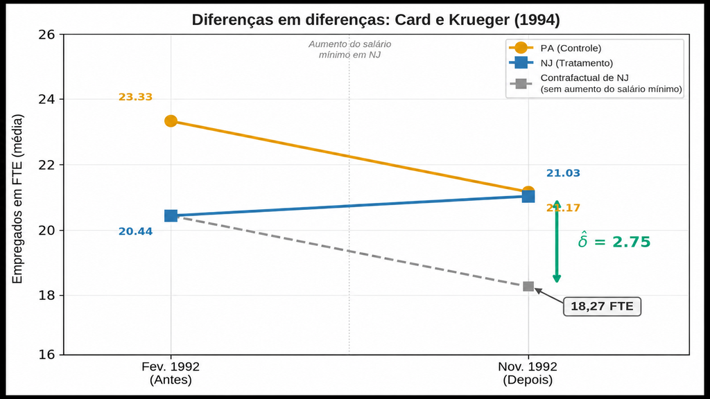

Sob tendências paralelas, o tracejado mostra como o emprego em NJ teria mudado sem a política, seguindo a variação observada em PA.

## Diferenças em diferenças

### Construção do contrafactual

Aplicamos a variação observada em PA ao emprego médio inicial de NJ.

$$\begin{aligned}
\widehat{\bar y}^{(0)}_{\mathrm{NJ},\text{pós}}
&= \bar y_{\mathrm{NJ},\text{pré}} + \Delta\bar y_{\mathrm{PA}} \\
&= 20{,}4394 + (21{,}1656 - 23{,}3312) \\
&= 18{,}2738 \approx 18{,}27\ \text{FTE}.
\end{aligned}$$

A distância entre o emprego observado em NJ após a política e esse contrafactual é a estimativa DiD.

$$\hat\delta=21{,}0274-18{,}2738=2{,}7536\approx 2{,}75\ \text{FTE}.$$

## DiD como uma regressão

### Da tabela $2\times2$ a uma regressão

A estimativa de **diferenças em diferenças** também pode ser obtida por uma única regressão linear, estimada por MQO:

$$y_{it}=\beta_1+\beta_2\mathrm{NJ}_i+\beta_3\mathrm{Depois}_t
+\delta\,(\mathrm{NJ}_i\times\mathrm{Depois}_t)+u_{it}$$

Em que $y_{it}$ representa o emprego (FTE) no restaurante $i$, no período $t$.

**Essa regressão utiliza variáveis que já conhecemos:**

- $\mathrm{NJ}_i$: uma **variável indicadora**, que vale 1 para restaurantes de NJ e 0 para restaurantes de PA.
- $\mathrm{Depois}_t$: outra **variável indicadora**, que vale 1 após o aumento do salário mínimo e 0 antes.
- $\mathrm{NJ}_i\times\mathrm{Depois}_t$: um **termo de interação**, que vale 1 apenas para restaurantes de NJ após a política.

$\implies$ No desenho com **dois grupos e dois períodos**, o coeficiente $\delta$ da interação recupera a estimativa DiD calculada na tabela $2\times2$.

## DiD como uma regressão

### O significado de cada coeficiente

$$y_{it}=\beta_1+\beta_2\mathrm{NJ}_i+\beta_3\mathrm{Depois}_t
+\delta\,(\mathrm{NJ}_i\times\mathrm{Depois}_t)+u_{it}$$

Substituindo os valores das variáveis indicadoras, obtemos a função de regressão para cada célula da tabela:

| Grupo | Antes ($\mathrm{Depois}=0$) | Depois ($\mathrm{Depois}=1$) |
| --- | --- | --- |
| PA ($\mathrm{NJ}=0$) | $\beta_1$ | $\beta_1+\beta_3$ |
| NJ ($\mathrm{NJ}=1$) | $\beta_1+\beta_2$ | $\beta_1+\beta_2+\beta_3+\delta$ |

- $\hat\beta_1\approx23{,}33$: emprego médio em PA antes da política (**categoria de referência**).
- $\hat\beta_2\approx-2{,}89$: NJ apresentava emprego médio **2,89 FTE inferior** ao de PA antes da política.
- $\hat\beta_3\approx-2{,}17$: **variação temporal** do emprego médio em PA.
- $\hat\delta\approx2{,}75$: estimativa **DiD**, correspondente à diferença entre as variações do emprego em NJ e PA.

## DiD como uma regressão

### Verificação: $\delta$ recupera a fórmula DiD

A partir das quatro expressões da tabela anterior:

**Variação do emprego em NJ:**

$$(\beta_1+\beta_2+\beta_3+\delta)
-(\beta_1+\beta_2)
=\beta_3+\delta$$

**Variação do emprego em PA:**

$$(\beta_1+\beta_3)-\beta_1=\beta_3$$

**Diferença das diferenças:**

$$\underbrace{(\beta_3+\delta)}_{\text{variação em NJ}}
-
\underbrace{\beta_3}_{\text{variação em PA}}
=\delta$$

$\implies$ O coeficiente da interação corresponde exatamente à **diferença das diferenças**.

Estimado por MQO, $\hat\delta$ reproduz a estimativa da tabela $2\times2$: aproximadamente **2,75 FTE**.

## Card e Krueger (1994)

### Resultados e conclusão do estudo

**Resultado empírico:** a estimativa DiD indica um aumento relativo do emprego de aproximadamente **2,75 trabalhadores equivalentes em tempo integral (FTE)** por restaurante em Nova Jersey, comparativamente à Pensilvânia.

**Conclusão de Card e Krueger (1994):** os autores não encontraram evidências de que o aumento do salário mínimo tenha reduzido o emprego nos restaurantes investigados. As estimativas apontaram, ao contrário, para um **efeito positivo sobre o emprego**.

**Implicação:** os resultados contrariaram a previsão de redução do emprego do modelo competitivo convencional do mercado de trabalho.

## Modelo de Efeitos fixos *two-way*

### Painel com dois períodos

Na avaliação de um **programa de treinamento de trabalhadores**, duas fontes de confundimento podem comprometer a estimação:

- **Heterogeneidade individual ($\alpha_i$):** características não observadas das empresas, como capacidade gerencial e habilidades dos trabalhadores, podem estar relacionadas à participação no programa. Os efeitos fixos individuais eliminam o componente **constante ao longo do tempo**.
- **Choques temporais ($\lambda_t$):** mudanças na conjuntura econômica podem afetar a produtividade de todas as empresas, independentemente do programa. Os efeitos fixos temporais controlam essas **variações comuns a cada período**.

No desenho com **tratamento simultâneo** e **grupo de controle nunca tratado**, o modelo de efeitos fixos *two-way* permite estimar a mudança adicional do grupo tratado em relação ao controle, após considerar esses dois componentes.

**Limitação:** os efeitos fixos não eliminam choques específicos aos grupos que variam no tempo. A interpretação causal continua dependendo da **hipótese de tendências paralelas**.

## Avaliação de subsídios para treinamento (Wooldridge, 2025)

### Modelo de Efeitos fixos *two-way*: Painel com dois períodos

Um programa em Michigan (EUA) subsidiou o treinamento de trabalhadores de empresas industriais. **Receber o subsídio reduziu a taxa de produtos defeituosos?**

- A base `JTRAIN` cobre 1987–1989. A análise usa **1987 (pré) e 1988 (pós)**, com **54 empresas e 108 registros empresa-ano**.
- `grant` indica o recebimento do subsídio. Em 1988, **19 empresas** receberam (tratadas) e **35** ficaram sem (controles).
- `scrap` conta os descartes por defeito a cada 100 itens produzidos. Uma taxa maior indica maior incidência de descartes por defeito na produção.

### Por que usar DiD?

Comparar os níveis de defeitos pode confundir o efeito do subsídio com a heterogeneidade individual não observada, como a habilidade dos trabalhadores e a capacidade gerencial.

O DiD compara a **variação média entre 1987 e 1988** das empresas tratadas com a das empresas de controle, eliminando a **heterogeneidade individual constante no tempo** e as **mudanças temporais comuns aos grupos**. A interpretação causal depende da hipótese de tendências paralelas.

## Avaliação de subsídios para treinamento

### Modelo DiD com efeitos fixos *two-way*

Para avaliar o efeito do subsídio sobre a **taxa de produtos defeituosos**, estimamos:

$$\mathrm{scrap}_{it}
=\alpha_i+\lambda_t+\delta\,\mathrm{grant}_{it}+u_{it}$$

- $\mathrm{scrap}_{it}$: número de itens defeituosos por 100 produzidos na empresa $i$, no ano $t$ (1987 ou 1988).
- $\alpha_i$: **efeito fixo da empresa**, que controla características não observadas constantes no tempo.
- $\lambda_t$: **efeito fixo do ano**, que controla mudanças temporais comuns às empresas.
- $\mathrm{grant}_{it}$: indicador igual a **1** se a empresa recebeu o subsídio em 1988 e **0** caso contrário.
- $\delta$: **coeficiente DiD**, que mede a diferença entre as variações médias da taxa de defeitos das empresas tratadas e das empresas de controle.
- $u_{it}$: erro idiossincrático.

## Avaliação de subsídios para treinamento

### Preparação dos dados

```r
# Carrega os dados sobre o subsídio ao treinamento.
data("jtrain", package = "wooldridge")

# Parte da base jtrain e guarda o resultado em jtrain_painel.
jtrain_painel <- jtrain |>
  # Filtra as linhas de 1987 e 1988 em que a taxa de defeitos e seu
  # logaritmo têm valores finitos (sem ausências nem infinitos).
  filter(year %in% c(1987, 1988) &
         is.finite(scrap) &
         is.finite(lscrap)) |>
  # Agrupa as linhas por empresa (fcode) para contar as observações.
  group_by(fcode) |>
  # Filtra as linhas de empresas com duas observações, uma por ano.
  filter(n() == 2) |>
  # Desfaz o agrupamento para contar as empresas por ano e subsídio.
  ungroup() |>
  # Seleciona as cinco variáveis usadas na aplicação.
  select(fcode, year, grant, scrap, lscrap)

# Mostra as duas observações anuais de cada uma das cinco primeiras empresas.
head(jtrain_painel, 10)
```

## Avaliação de subsídios para treinamento

```
# A tibble: 10 × 5
    fcode  year grant   scrap lscrap
    <dbl> <int> <int>   <dbl>  <dbl>
 1 410523  1987     0  0.0600 -2.81
 2 410523  1988     0  0.0500 -3.00
 3 410538  1987     0  2.64    0.971
 4 410538  1988     0  2.74    1.01
 5 410563  1987     0  6       1.79
 6 410563  1988     0  7       1.95
 7 410565  1987     0 21       3.04
 8 410565  1988     0 11       2.40
 9 410566  1987     0  7       1.95
10 410566  1988     0  5       1.61
```

## Avaliação de subsídios para treinamento

### Empresas com e sem subsídio por ano

```r
# Usa o painel balanceado preparado no slide anterior.
jtrain_painel |>
  # Conta as empresas por ano, com subsídio (grant = 1) ou sem (grant = 0).
  count(year, grant, name = "empresas")
```

```
# A tibble: 3 × 3
   year grant empresas
  <int> <int>    <int>
1  1987     0       54
2  1988     0       35
3  1988     1       19
```

- **1987 (antes do subsídio):** as 54 empresas têm `grant = 0`, inclusive as que receberiam o subsídio em 1988.
- **1988 (ano do subsídio):** 19 empresas receberam o subsídio (`grant = 1`) e formam o grupo tratado. As outras 35 (`grant = 0`) formam o grupo de controle.

## Avaliação de subsídios para treinamento

### Estimação de efeitos fixos com `fixest`

O pacote `fixest` permite estimar modelos lineares com efeitos fixos usando `feols()`. Na fórmula, o operador `|` separa os **regressores** dos **efeitos fixos**.

**Efeitos fixos de empresa (*one-way*):**

```r
fixest::feols(scrap ~ grant | fcode,
              data = jtrain_painel)
```

**Efeitos fixos de empresa e ano (*two-way*):**

```r
fixest::feols(scrap ~ grant | fcode + year,
              data = jtrain_painel)
```

- **`grant`:** variável indicadora que já representa a interação entre o grupo tratado e o período posterior, assumindo valor **1 apenas para empresas que receberam o subsídio em 1988**.
- `fcode`: controla características das empresas constantes no tempo.
- `year`: controla mudanças temporais comuns às empresas.

$\implies$ Para estimar o **DiD deste exemplo**, utilizaremos o modelo *two-way*, que incorpora os efeitos fixos de **empresa** (individuais) e de **ano** (tempo).

## Avaliação de subsídios para treinamento

### Por que `grant` já representa a interação DiD?

Considere duas variáveis indicadoras:

- $\mathrm{Trt}_i=1$ para as empresas que **receberam o subsídio em 1988**; vale 0 para as demais.
- $\mathrm{Pós}_t=1$ para **1988**; vale 0 para 1987.

| Grupo / ano | $\mathrm{Trt}_i$ | $\mathrm{Pós}_t$ | $\mathrm{Trt}_i\times\mathrm{Pós}_t$ | `grant` |
| --- | --- | --- | --- | --- |
| Controle / 1987 | 0 | 0 | 0 | 0 |
| Controle / 1988 | 0 | 1 | 0 | 0 |
| Tratamento / 1987 | 1 | 0 | 0 | 0 |
| Tratamento / 1988 | 1 | 1 | **1** | **1** |

As duas últimas colunas são **idênticas**:

$$\boxed{\mathrm{grant}_{it}=\mathrm{Trt}_i\times\mathrm{Pós}_t}$$

$\implies$ A interação **já está incluída** no modelo por meio de `grant`. Acrescentar outra interação seria duplicar a mesma variável, produzindo **colinearidade perfeita**.

## Avaliação de subsídios para treinamento

### Estimação do modelo de efeitos fixos *two-way*

```r
# Estima o modelo em níveis com efeitos fixos de empresa e ano.
modelo_ef_nivel <- fixest::feols(scrap ~ grant | fcode + year,
                                data = jtrain_painel, vcov = "iid")

broom::tidy((modelo_ef_nivel))
```

```
# A tibble: 1 × 5
  term  estimate std.error statistic p.value
  <chr>    <dbl>     <dbl>     <dbl>   <dbl>
1 grant   -0.739     0.683     -1.08   0.284
```

```r
# Repete a especificação com o logaritmo da taxa de defeitos.
modelo_ef_log <- fixest::feols(lscrap ~ grant | fcode + year,
                              data = jtrain_painel, vcov = "iid")

broom::tidy(summary(modelo_ef_log))
```

```
# A tibble: 1 × 5
  term  estimate std.error statistic p.value
  <chr>    <dbl>     <dbl>     <dbl>   <dbl>
1 grant   -0.317     0.164     -1.93  0.0585
```

## Avaliação de subsídios para treinamento

| Estatística | Níveis | Logaritmos |
| --- | --- | --- |
| Coeficiente de grant | -0,739 | -0,317 |
| IC de 95% | [-2,109; 0,630] | [-0,646; 0,012] |
| EP convencional | 0,683 | 0,164 |
| Valor-p | 0,284 | 0,058 |

*54 empresas (108 observações empresa-ano). Erros-padrão convencionais e intervalos de confiança de 95%.*

**Incerteza:** ambos os intervalos de confiança de 95% incluem zero. No modelo logarítmico, o intervalo é compatível com variações de aproximadamente **−47,6% a +1,2%** na taxa de defeitos.

**Conclusão:** nesta avaliação, os resultados não fornecem evidência estatística suficientemente convincente de que o subsídio tenha reduzido a taxa de defeitos. Isso não demonstra a ausência de efeito. Uma avaliação mais abrangente da eficácia do programa requer considerar a qualidade dos dados, a condução do estudo e as evidências produzidas por outras pesquisas.

Diferença-em-Diferenças com painel com múltiplos períodos

## Diferenças em diferenças

### DiD com múltiplos períodos

Com **dois períodos**, o DiD compara as mudanças médias dos grupos tratado e de controle. Com **múltiplos períodos**, podemos comparar as médias de vários períodos anteriores e posteriores à intervenção.

$$\hat{\delta}_{DiD}
=
(\bar y_{Trt,pós}-\bar y_{Trt,pré})
-
(\bar y_{Ctrl,pós}-\bar y_{Ctrl,pré})$$

- **Estimação:** os efeitos fixos individuais controlam a **heterogeneidade não observada, específica de cada unidade e constante no tempo**; os efeitos temporais controlam **choques agregados, comuns às unidades e variáveis ao longo do tempo**.
- **Neste desenho balanceado**, sem covariáveis adicionais e com um grupo nunca tratado, o coeficiente DiD estimado por efeitos fixos bidirecionais coincide com a dupla diferença das médias pré e pós.

## Diferenças em diferenças

### A vantagem dos múltiplos períodos

Com vários períodos, podemos observar as **trajetórias dos grupos antes e depois da intervenção**.

- **Antes do tratamento:** podemos examinar se os grupos apresentavam tendências semelhantes, avaliando a plausibilidade da hipótese de **tendências paralelas**.
- **Depois do tratamento:** podemos acompanhar a evolução das diferenças entre os grupos e identificar se elas aumentam, diminuem ou permanecem estáveis.

$\implies$ Trajetórias paralelas antes da intervenção **fortalecem a plausibilidade** da hipótese, mas não garantem que continuariam paralelas na ausência do tratamento.

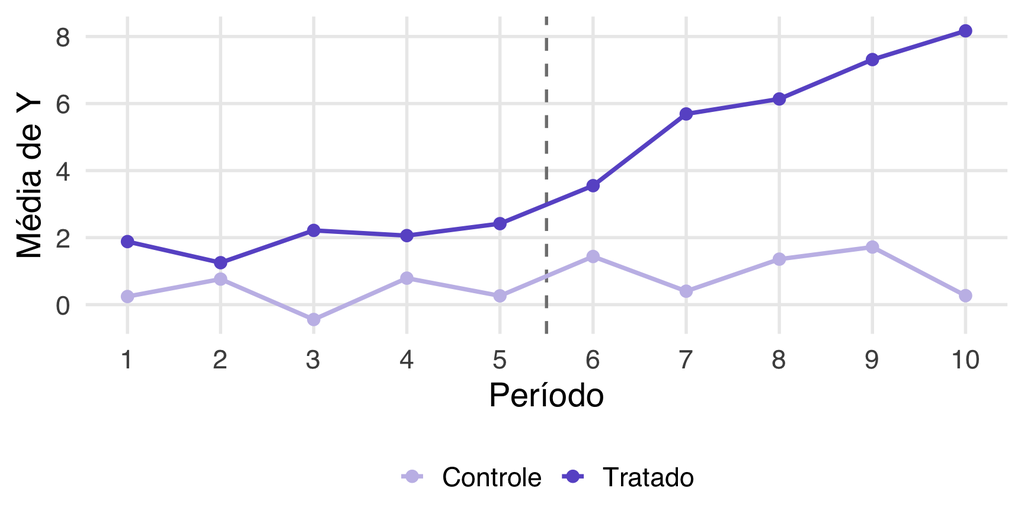

DiD em gráficos (O tratamento começa entre os períodos 5 e 6.)

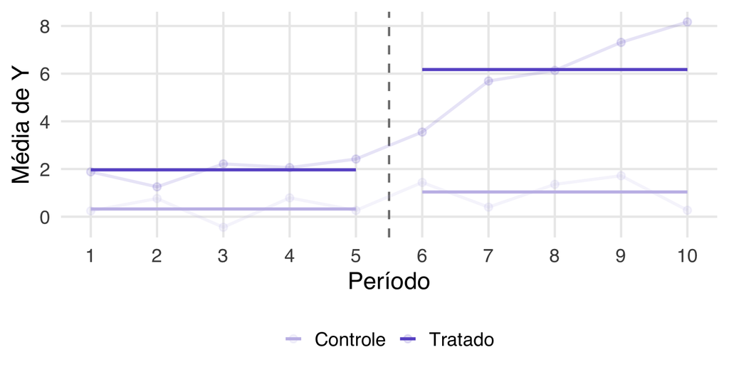

Aqui vemos as médias por grupo e período.

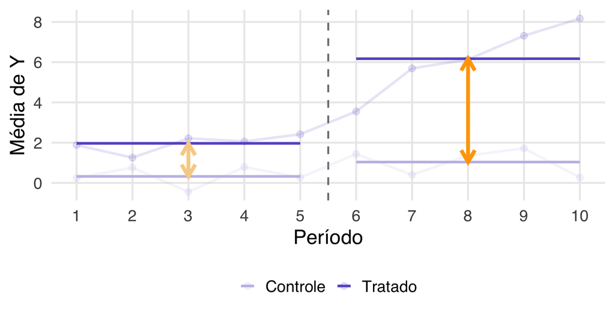

A estimativa de DiD compara a diferença pré-tratamento com a diferença pós-tratamento.

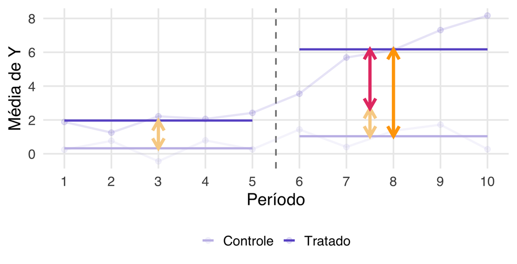

A diferença entre as diferenças pré-tratamento e pós-tratamento é a estimativa de DiD.

## DiD como uma regressão

### Painel com múltiplos períodos

Nos gráficos, a estimativa DiD corresponde à **mudança na diferença média entre os grupos**:

$$\hat{\delta}_{DiD}
=
\underbrace{(\bar y_{Trt,pós}-\bar y_{Ctrl,pós})}_{\text{diferença após}}
-
\underbrace{(\bar y_{Trt,pré}-\bar y_{Ctrl,pré})}_{\text{diferença antes}}$$

Podemos obter essa estimativa por uma **regressão linear com efeitos fixos**:

- Os **efeitos fixos individuais** controlam diferenças permanentes entre as unidades.
- Os **efeitos fixos temporais** controlam mudanças comuns aos grupos em cada período.
- O coeficiente da interação **tratamento × período posterior** mede a mudança adicional do grupo tratado em relação ao controle.

$\implies$ Neste painel balanceado, com tratamento simultâneo e sem outras covariáveis, o coeficiente estimado da interação, $\hat{\delta}$, **coincide com a dupla diferença das médias pré e pós-tratamento**.

## DiD como uma regressão

### Modelo geral de avaliação de políticas

Com dados em painel, podemos estimar um modelo com **efeitos fixos individuais e temporais**, incluindo variáveis de controle (Wooldridge, 2025):

$$\boxed{
y_{it}=\alpha_i+\lambda_t+
\delta D_{it}+\mathbf{x}_{it}'\boldsymbol{\beta}+u_{it}
}$$

- $y_{it}$: **variável dependente** da unidade $i$ no período $t$.
- $\alpha_i$ e $\lambda_t$: **efeitos fixos individuais e temporais**, respectivamente.
- $D_{it}$: indicador igual a **1 quando a unidade está sob tratamento** no período $t$, e 0 caso contrário; $\delta$ é seu coeficiente.
- $\mathbf{x}_{it}'\boldsymbol{\beta}$: **variáveis de controle adicionais** e seus coeficientes; $u_{it}$ é o erro idiossincrático.

## Diferenças em diferenças

### Registro de doadores de órgãos (Huntington-Klein, 2025)

O estudo de Kessler e Roth (2014) investiga como a **forma de solicitar o consentimento para a doação de órgãos** influencia a taxa de registro de doadores nos Estados Unidos.

- **Procedimento tradicional (*opt-in*):** ao solicitar a carteira de habilitação, o cidadão pode optar por se registrar como doador, marcando voluntariamente a opção correspondente.
- **Escolha ativa (*active choice*):** o cidadão precisa responder explicitamente **“sim” ou “não”** à pergunta sobre o registro como doador.
- **Intervenção:** em julho de 2011, a Califórnia substituiu o procedimento *opt-in* pela escolha ativa.
- **Questão de pesquisa:** exigir uma escolha explícita aumenta a **taxa de registro de doadores de órgãos**?

## Diferenças em diferenças

### Dados e grupos de comparação

A base `organ_donations`, disponível no pacote R `causaldata`, contém informações trimestrais sobre o **registro de doadores de órgãos** nos Estados Unidos.

- **Estrutura:** painel com 27 unidades territoriais e 6 trimestres, totalizando **162 observações**.
- **Período:** do quarto trimestre de 2010 ao primeiro trimestre de 2012, sendo **3 trimestres anteriores e 3 posteriores** à intervenção.
- **Variável dependente:** `Rate`, taxa de registro de doadores, expressa como proporção.
- **Identificação do painel:** `State` (unidade territorial) e `Quarter` (trimestre).

| Grupo | Antes: 2010 T4–2011 T2 | Depois: 2011 T3–2012 T1 |
| --- | --- | --- |
| **Califórnia (tratado)** | Adesão voluntária | Escolha ativa |
| **Demais unidades (controle)** | Sem intervenção | Sem intervenção |

$\implies$ O DiD compara a **variação da taxa de registro na Califórnia** com a variação observada nas unidades de controle.

## DiD como uma regressão

### Modelo com efeitos fixos

Para avaliar a mudança no procedimento de registro de doadores, estimamos um modelo com **efeitos fixos de estado e trimestre**:

$$\boxed{
Rate_{it}=\alpha_i+\lambda_t+\delta\,Treated_{it}+u_{it}
}$$

- $\alpha_i$: **efeitos fixos de estado**, que controlam a heterogeneidade não observada, específica de cada estado e constante ao longo do tempo.
- $\lambda_t$: **efeitos fixos temporais**, que controlam fatores agregados que variam ao longo do tempo e afetam todos os estados.
- $Treated_{it}$: indicador igual a **1 para a Califórnia a partir do terceiro trimestre de 2011**, e 0 nas demais observações.

**Coeficiente DiD ($\delta$):** mede a diferença entre a variação da taxa de registro na Califórnia e a variação observada nos estados de controle, antes e depois da intervenção.

Como `Rate` é uma proporção, $100\delta$ expressa essa diferença em **pontos percentuais**.

## Diferenças em diferenças

### Preparação dos dados

```r
# Carrega os dados utilizados na aplicação de Klein.
od <- causaldata::organ_donations

# Identifica a Califórnia nos trimestres posteriores à intervenção.
od <- od |>
  mutate(
    Treated = as.integer(
      State == "California" &
        Quarter %in% c("Q32011", "Q42011", "Q12012")
    )
  )

# Exibe as primeiras linhas do objeto
head(od, 10)
```

```
# A tibble: 10 × 5
   State   Quarter  Rate Quarter_Num Treated
   <chr>   <chr>   <dbl>       <int>   <int>
 1 Alaska  Q42010  0.75            1       0
 2 Alaska  Q12011  0.77            2       0
 3 Alaska  Q22011  0.77            3       0
 4 Alaska  Q32011  0.78            4       0
 5 Alaska  Q42011  0.78            5       0
 6 Alaska  Q12012  0.79            6       0
 7 Arizona Q42010  0.263           1       0
 8 Arizona Q12011  0.209           2       0
 9 Arizona Q22011  0.226           3       0
10 Arizona Q32011  0.250           4       0
```

A variável `Treated` identifica as observações que receberam a intervenção. Seu valor é **1** para a Califórnia nos três últimos trimestres e **0** nas demais observações.

## DiD como uma regressão

### Erros-padrão agrupados por estado

No artigo de Kessler e Roth (2014), cada estado é observado durante **seis trimestres**. Os erros de observações de um mesmo estado podem estar correlacionados ao longo do tempo.

- **Problema:** ignorar essa dependência pode produzir erros-padrão inadequados, comprometendo os testes de hipóteses e os intervalos de confiança.
- **Solução:** utilizar **erros-padrão robustos a agrupamentos por estado**, que permitem heterocedasticidade e correlação entre os erros das observações de um mesmo estado.
- **Importante:** os efeitos fixos fazem parte da **especificação do modelo**, enquanto os erros-padrão agrupados ajustam a **inferência estatística**, sem modificar as estimativas dos coeficientes.

No `fixest`, especificamos o agrupamento por estado utilizando: `vcov = ~State`

**Limitação:** como apenas a Califórnia recebe o tratamento, os erros-padrão agrupados por estado podem subestimar a incerteza da estimativa DiD.

Estimação do DiD com `fixest`

```r
# Estima o DiD com efeitos fixos de estado e trimestre.
modelo_did <- feols(
  Rate ~ Treated | State + Quarter,
  data = od,
  vcov = ~State
)

# Apresenta as estimativas e os erros-padrão agrupados por estado.
etable(
  modelo_did,
  dict = c(Treated = "Tratamento"),
  coefstat = "confint",
  extralines = list(
    "Erro-padrão" = round(se(modelo_did)["Treated"], 3)
  ),
  signif.code = NA,
  digits = 3
)
```

```
                             modelo_did
Dependent Var.:                    Rate

Tratamento      -0.022 [-0.035; -0.010]
Erro-padrão                      0.006
Fixed-Effects:  -----------------------
State                               Yes
Quarter                             Yes
_______________ _______________________
VCOV: Clustered               by: State
Observations                        162
R2                              0.97932
Within R2                       0.00922
```

## Diferenças em diferenças

### Resultados e conclusão

A estimação do modelo com efeitos fixos de estado e trimestre produziu os seguintes resultados:

- **Estimativa DiD:** $\hat{\delta}=-0{,}022$, equivalente a **−2,2 pontos percentuais**.
- **Intervalo de confiança de 95%:** $[-0{,}035;\,-0{,}010]$, equivalente a **[−3,5; −1,0] pontos percentuais**.
- **Incerteza da estimativa:** o intervalo indica que os resultados são compatíveis com uma redução relativa da taxa de registro entre **1,0 e 3,5 pontos percentuais**.

**Interpretação:** após a adoção da escolha ativa, a variação da taxa de registro na Califórnia foi estimada em **2,2 pontos percentuais abaixo** da observada nos estados de controle.

$\implies$ **Conclusão:** a mudança para escolha ativa não aumentou o registro de doadores. A estimativa DiD indica, ao contrário, uma **redução relativa na taxa de registro**, cuja magnitude está sujeita à incerteza expressa pelo intervalo de confiança.

## Diferenças em diferenças

### Avaliação da hipótese de tendências paralelas

Como a hipótese de **tendências paralelas** envolve uma trajetória contrafactual não observável, podemos buscar evidências que fortaleçam sua plausibilidade.

- **Inspeção gráfica:** comparar as trajetórias médias dos grupos antes da intervenção, verificando se a diferença entre eles permaneceu aproximadamente constante.
- **Regressão de tendências anteriores:** utilizando apenas dados pré-tratamento, estimar se as tendências diferem entre os grupos, avaliando a magnitude e a incerteza dessa diferença.
- **Testes placebo:** atribuir datas fictícias de tratamento em períodos anteriores à intervenção e reestimar o DiD. Efeitos aparentes relevantes nesses períodos podem indicar problemas no desenho de pesquisa.

$\implies$ Esses procedimentos fornecem **evidências indiretas** sobre a plausibilidade da hipótese, mas **não comprovam** que as tendências teriam permanecido paralelas na ausência do tratamento.

## Diferenças em diferenças

### Tendências anteriores à intervenção

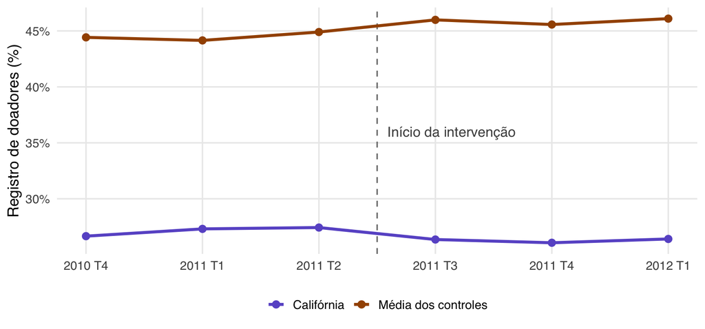

Antes da intervenção, a diferença entre as taxas de registro da Califórnia e dos controles oscilou entre 16,84 e 17,77 pontos percentuais, sem apresentar divergência persistente. Após a intervenção (linha tracejada), a distância entre os grupos aumentou.

## Diferenças em diferenças

### Interpretação das trajetórias observadas

O gráfico permite examinar a evolução das taxas de registro na Califórnia e nos estados de controle, antes e depois da intervenção.

- **Diferenças de níveis:** as taxas dos controles são superiores às da Califórnia, mas a hipótese de tendências paralelas não exige níveis semelhantes.
- **Antes da intervenção:** a diferença entre os grupos oscilou entre **16,84 e 17,77 pontos percentuais**, sem apresentar uma tendência persistente de aumento ou redução.
- **Depois da intervenção:** a distância entre os grupos aumentou, com evolução relativamente desfavorável da taxa de registro na Califórnia.

$\implies$ **Conclusão:** as trajetórias anteriores não revelam uma divergência sistemática evidente. Esse comportamento é **compatível com a hipótese de tendências paralelas**, mas não comprova sua validade.

## Diferenças em diferenças

### O que ameaça DiD?

O DiD depende de que a **variação no grupo de controle represente a variação que teria ocorrido no grupo tratado na ausência da intervenção**.

**Ameaças à identificação causal:**

- **Tendências contrafactuais distintas:** mesmo sem a intervenção, os grupos teriam apresentado evoluções diferentes.
- **Mudanças simultâneas:** outros acontecimentos afetam especificamente um dos grupos no período da intervenção, confundindo seus efeitos com os do tratamento.

**Problemas de especificação e estimação:**

- **Variáveis de controle inadequadas:** incluir variáveis afetadas pelo tratamento pode distorcer o efeito causal estimado.
- **Implementação gradual (*rollout designs*):** grupos recebem o tratamento em momentos diferentes. Quando os efeitos são **heterogêneos entre grupos ou dinâmicos no tempo**, o estimador com efeitos fixos bidirecionais pode utilizar unidades já tratadas como controles, comprometendo a interpretação do coeficiente DiD.

## Diferenças em diferenças

### Quando utilizar o DiD?

O DiD convencional é especialmente adequado quando a **variação observada no grupo de controle** representa de forma plausível a **variação contrafactual do grupo tratado**, isto é, aquela que teria ocorrido na ausência da intervenção.

- **Intervenção bem definida e simultânea:** sabemos quais unidades receberam o tratamento, e todas as unidades tratadas começaram a recebê-lo no mesmo período.
- **Dados anteriores e posteriores:** observamos os grupos antes e depois da intervenção. Vários períodos anteriores ajudam a avaliar a plausibilidade de tendências paralelas.
- **Grupo de comparação adequado:** informações sobre os grupos e suas trajetórias anteriores sustentam a plausibilidade da hipótese de **tendências paralelas**.

Uma alternativa — **controle sintético:** quando uma comparação simples não é convincente, podemos construir um grupo de controle sintético, combinando unidades não tratadas por meio de **pesos escolhidos para aproximar a trajetória da unidade tratada antes da intervenção**.

## Diferenças em diferenças - Síntese

O DiD busca estimar o **efeito causal de uma intervenção**, utilizando a evolução do grupo de controle para aproximar a **variação contrafactual do grupo tratado**.

- **Dupla diferença:** compara a mudança da variável dependente no grupo tratado com a mudança observada no grupo de controle.
- **Identificação causal:** depende da hipótese de **tendências paralelas** — na ausência da intervenção, os grupos teriam apresentado a mesma evolução média.
- **Estimação com efeitos fixos:** os efeitos individuais controlam a **heterogeneidade não observada constante no tempo**; os temporais controlam **fatores agregados que variam entre períodos e afetam todas as unidades**.
- **Múltiplos períodos:** permitem examinar as trajetórias anteriores e posteriores à intervenção, reunindo evidências sobre a plausibilidade de tendências paralelas.
- **Inferência:** erros-padrão agrupados consideram a dependência dentro das unidades, enquanto os intervalos de confiança expressam a **incerteza e as magnitudes compatíveis com os dados**.

$\implies$ A **interpretação causal** da estimativa DiD depende da credibilidade do desenho de pesquisa e de suas hipóteses, não apenas da estimação da regressão.

## Aplicações de DiD no Brasil: Finanças

- **[Grimaldi e Ornelas (2024)](https://aprendervalor.bcb.gov.br/content/publicacoes/WorkingPaperSeries/WP599v2.pdf)** — *Banco Central do Brasil*.

  **Pergunta:** subsídios ao crédito promovem o crescimento das empresas, em termos de emprego e folha salarial?
- **[Martini et al. (2025)](https://web.bndes.gov.br/bib/jspui/handle/1408/26227)** — *BNDES*.

  **Pergunta:** o financiamento público aumenta o investimento e o desempenho econômico das empresas beneficiadas?
- **[Alves (2018)](https://doi.org/10.11606/T.12.2018.tde-07062018-122947)** — *Tese de Doutorado, USP*.

  **Pergunta:** a introdução de regras tributárias de subcapitalização alterou a estrutura de capital das multinacionais brasileiras?

## Aplicações de DiD no Brasil: Governança e Desastres

- **[Figo (2019)](https://doi.org/10.11606/D.12.2019.tde-17102019-161158)** — *Dissertação de Mestrado, USP*.

  **Pergunta:** mudanças regulatórias na estrutura de governança afetaram o desempenho financeiro das cooperativas de crédito?
- **[FGV (2020)](https://www.mpf.mp.br/atuacao/como-e-a-atuacao-do-mpf/casos-de-destaque/caso-samarco/documentos/fgv/mercado-de-trabalho-formal.pdf/@@download/file)** — *Projeto Rio Doce, relatório técnico*.

  **Pergunta:** o rompimento da barragem de Fundão, em Mariana, afetou o emprego formal e a massa salarial dos municípios atingidos?
- **[Gonzalez et al. (2023)](https://doi.org/10.18235/0005312)** — *BID / Banco Central do Brasil*.

  **Pergunta:** o desastre de Mariana afetou as transações financeiras das empresas e os gastos das famílias?

## Pedro H. C. Sant’Anna: contribuições ao DiD

### Pesquisa econométrica e desenvolvimento de ferramentas em R

O econometrista brasileiro **Pedro H. C. Sant’Anna** é coautor de importantes contribuições recentes à identificação e estimação de efeitos causais por diferenças em diferenças.

- **[Sant’Anna e Zhao (2020)](https://doi.org/10.1016/j.jeconom.2020.06.003)** — *Journal of Econometrics*: estimadores de DiD duplamente robustos.
- **[Callaway e Sant’Anna (2021)](https://doi.org/10.1016/j.jeconom.2020.12.001)** — *Journal of Econometrics*: DiD com múltiplos períodos e diferentes momentos de adoção do tratamento.
- **[Baker et al. (2026)](https://doi.org/10.1257/jel.20251650)** — *Journal of Economic Literature*: guia abrangente sobre desenhos de pesquisa e estimadores de DiD.

**Pacote R [`did`](https://bcallaway11.github.io/did/):** desenvolvido com Brantly Callaway, permite estimar efeitos do tratamento por grupo e período, além de seus efeitos agregados.

**[Página de recursos de Sant’Anna](https://psantanna.com/did-resources/):** artigos, slides, códigos e materiais de apoio.

Atividade 6

[Veja na página Cronograma do site da disciplina](https://washingtonsilva.github.io/site_mpa_ecnt03_2026/cronograma.html)

## Referências

ANGRIST, J. D.; PISCHKE, J.-S. [The Credibility Revolution in Empirical Economics: How Better Research Design Is Taking the Con out of Econometrics](https://doi.org/10.1257/jep.24.2.3). **Journal of Economic Perspectives**, v. 24, n. 2, p. 3–30, 2010.

ANGRIST, J. D.; PISCHKE, J.-S. **[Mastering ’Metrics: The Path from Cause to Effect](https://press.princeton.edu/books/paperback/9780691152844/mastering-metrics)**. Princeton, NJ: Princeton University Press, 2014.

CARD, D.; KRUEGER, A. B. [Minimum Wages and Employment: A Case Study of the Fast-Food Industry in New Jersey and Pennsylvania](https://www.jstor.org/stable/2118030). **American Economic Review**, v. 84, n. 4, p. 772–793, 1994.

HANSEN, B. E. **Econometrics**. Princeton, NJ: Princeton University Press, 2022.

HILL, R. C.; GRIFFITHS, W. E.; LIM, G. C. **Principles of Econometrics**. 5. ed. Hoboken, NJ: John Wiley & Sons, 2018.

HUNTINGTON-KLEIN, N. **[The Effect: An Introduction to Research Design and Causality](https://doi.org/10.1201/9781003448969)**. 2. ed. Boca Raton, FL: Chapman; Hall/CRC, 2025.

KESSLER, J. B.; ROTH, A. E. **Don’t Take ’No’ for an Answer: An Experiment with Actual Organ Donor Registrations**. [s.l.] National Bureau of Economic Research, ago. 2014. Disponível em: <https://doi.org/10.3386/w20378>.

LEAMER, E. E. Let’s Take the Con Out of Econometrics. **American Economic Review**, v. 73, n. 1, p. 31–43, 1983.

___. [Tantalus on the Road to Asymptopia](https://doi.org/10.1257/jep.24.2.31). **Journal of Economic Perspectives**, v. 24, n. 2, p. 31–46, 2010.

WOOLDRIDGE, J. M. **Introductory Econometrics: A Modern Approach**. 8. ed. [s.l.] Cengage Learning, 2025.